# EDA Laboratório 1 - Checkpoint 3

# 3. Longevidade

A longevidade de uma série está necessariamente associada a sua avaliação? Eu poderia escolher uma amostra para responder essa pergunta, mas usarei o conjunto inteiro de séries para ter um panorama melhor.

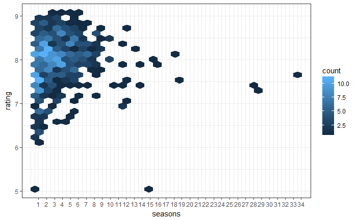

```r
series %>%
    group_by(series_name) %>%
    summarise(rating = round(mean(user_rating), 2), seasons = length(unique(season))) %>%
    ggplot(aes(x = seasons, y = rating)) +
    geom_hex() +
    scale_x_continuous(breaks = (1:34))
```

Através do gráfico é possível perceber que a grande maioria dos dados se encontra da metade para o topo no lado esquerdo e o que isso significa? Que grande parte das séries tem uma nota acima de 7 e tem apenas 4 temporadas. Infelizmente muitas das séries presentes no conjunto de dados são recentes e poderão ter mais temporadas, fazendo com que esse cenário possa ser diferente no futuro, porém é correto dizer que nem sempre a longevidade estarpa associada com a avaliação de uma série, afinal Survivor conta com 15 temporadas e tem uma nota próxima a 5.

# 4. Proporção de notas 1

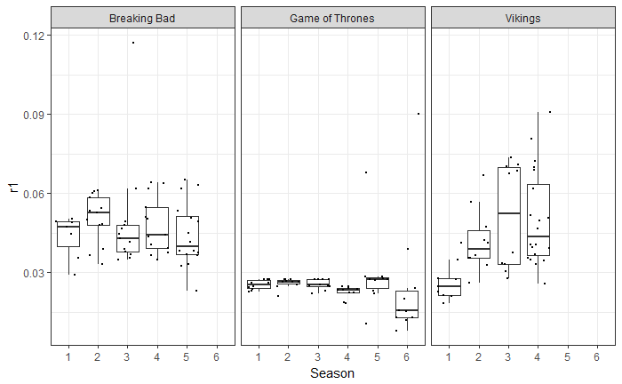

```r
    series %>%
    filter(series_name %in% c("Breaking Bad", "Game of Thrones", "Vikings")) %>%
    ggplot(aes(x = season, y = r1)) +
    geom_boxplot(outlier.colour = NA) +
    geom_jitter(size = .5) +
    facet_wrap(~ series_name, ncol = 3) +
    labs(x = "Season")
```

A afirmação não parece ser válida para nenhuma das séries. No caso de Breaking Bad a maior proporção de notas 1 foi na segunda temporada ficando entre 0.06 e 0.05, para Game Of Thrones a proporção nunca se alterou tanto, ficando abaixo de 0.03 e tendo apenas 3 exceções. Por fim, as maiores proporções de notas 1 em Vikings foram na terceira e quarta temporadas e não na primeira como esperado.

# 5. Breaking Bad

Breaking Bad é a minha série favorita e olhando o gráfico usado para responder a primeira pergunta, pude ver que no geral a sua qualidade foi aumentando com o passar das temporadas, será que isso fez com que mais pessoas tenham dado atenção à série? Isto é, a quantidade de pessoas dando notas aos episódios cresceu com o tempo?

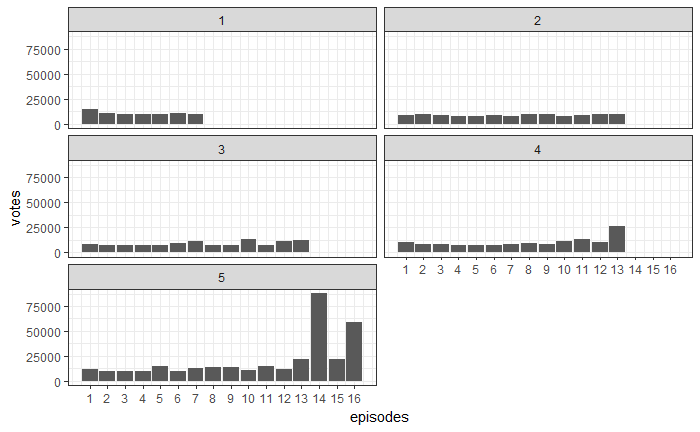

```r
series %>%
    filter(series_name == "Breaking Bad") %>%
    ggplot(aes(x = season_ep, y = user_votes)) +
    geom_bar(stat = "identity") +
    facet_wrap(~season, nrow = 3) +
    scale_x_continuous(breaks = c(1:16)) +
    labs(x = "episodes", y = "votes")
```

Ao contrário do que imaginei a audiência não foi crescendo no decorrer das temporadas, apenas no final da quinta temporada é que tivemos um aumento significativo da quantidade de pessoas votando na série. Isso porém não significa que a série não tivesse uma grande audiência, afinal estou analisando apenas o número de votos no site do IMDB.